# Structural analysis using stripped files

First, some data cleaning even before we match scans to clinical assessments:

```r
source('~/ncr_notebooks/baseline_prediction/src/aux_functions.R')
struct_data = read.csv('~/data/baseline_prediction/stripped/structural.csv')
# remove data columns from mean_data to avoid duplicates
par(mfrow=c(2, 2))
nbreaks = 40
hist(struct_data$CortexVol, breaks=nbreaks)
hist(struct_data$TotalGrayVol, breaks=nbreaks)
```

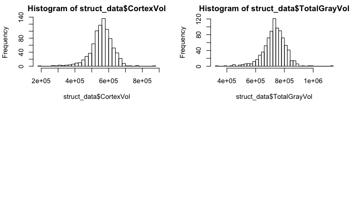

```r
hist(struct_data$SurfaceHoles, breaks=nbreaks)
```

[output not shown]

Even though we have a few outliers, it’s not clear whether these metrics would be good to filter the data. Let’s do it based on the good ol’ QC values:

```r
rm_me = (struct_data$mprage_score > 2)
print(sprintf('Reducing from %d to %d scans', nrow(struct_data), nrow(struct_data)-sum(rm_me)))
```

```
[1] "Reducing from 851 to 699 scans"
```

```r
struct_data = struct_data[!rm_me, ]
```

Now we work under the assumption that all leftover scans are good, so we match them to the baseline clinical of each participant:

```r
gf_fname = '~/data/baseline_prediction/stripped/clinical.csv'
gf = read.csv(gf_fname)
gf = gf[gf$BASELINE=='BASELINE', ]
my_ids = intersect(gf$MRN, struct_data$MRN)
merged = mergeOnClosestDate(gf, struct_data, my_ids)
```

Finally, let’s remove anyone with difference between clinical and scan that’s too big:

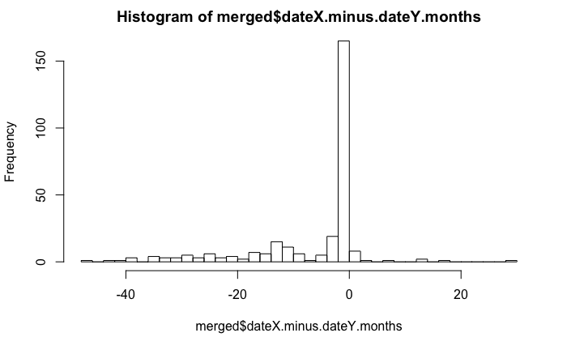

```r
hist(merged$dateX.minus.dateY.months, breaks=nbreaks)
```

There is clearly a big spread. Let’s err in the side of caution and cap it to 1 year before or after:

```r
rm_me = abs(merged$dateX.minus.dateY.months) > 12
print(sprintf('Reducing from %d to %d scans', nrow(merged), nrow(merged)-sum(rm_me)))
```

```
[1] "Reducing from 288 to 217 scans"
```

```r
merged = merged[!rm_me, ]
```

Ready for some ML. Let’s get all features first, and try some NV vs ADHD classification, clumping in the ADHD_NOS folks. We also do some quick random forest auto tuning just to appreciate all different variables:

```r
library(caret)
library(randomForest)
seed = 107
X = merged[, 33:302]
y = merged$DX_BASELINE
y[y != 'NV'] = 'ADHD'
y = factor(y)
```

```
mtry = 16  OOB error = 46.54%
Searching left ...
mtry = 11   OOB error = 47.93%
-0.02970297 1e-05
Searching right ...
mtry = 24   OOB error = 46.08%
0.00990099 1e-05
mtry = 36   OOB error = 45.62%
0.01 1e-05
mtry = 54   OOB error = 44.7%
0.02020202 1e-05
mtry = 81   OOB error = 41.47%
0.07216495 1e-05
mtry = 121  OOB error = 44.24%
-0.06666667 1e-05
```

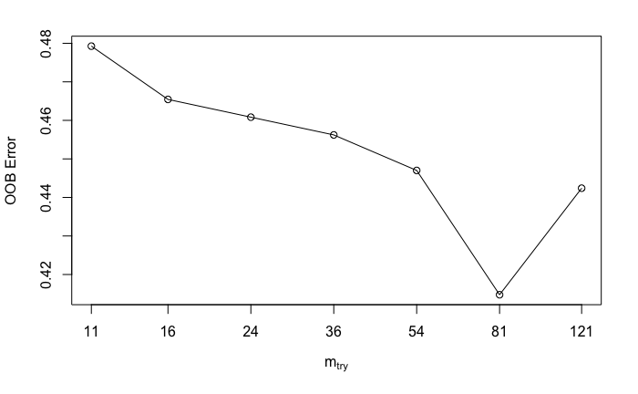

```r
ctrl = trainControl(method="repeatedcv", number=10, repeats=5, selectionFunction = "tolerance")
in_train = createDataPartition(y, p=.8, list=FALSE)
set.seed(seed)
bestmtry <- tuneRF(X, y, stepFactor=1.5, improve=1e-5, ntreeTry=2000, subset=in_train)
```

```r
print(bestmtry)
```

```
        mtry  OOBError
11.OOB    11 0.4792627
16.OOB    16 0.4654378
24.OOB    24 0.4608295
36.OOB    36 0.4562212
54.OOB    54 0.4470046
81.OOB    81 0.4147465
121.OOB  121 0.4423963
```

Still nothing to write home about… let’s do our old algorithms to see if we can get anything else out of it.

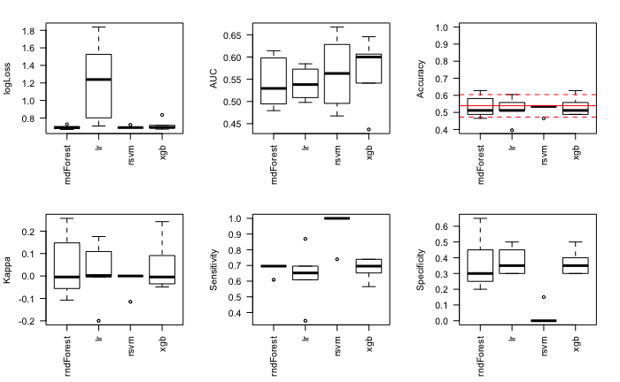

```r
ldata = X
groups = y
root_fname = '~/data/baseline_prediction/results/stripped_allStructural_NVvsADHD'
save(ldata, groups, file=sprintf('%s.RData', root_fname), compress=T)
#runInCluster(root_fname, train_test_ratio=.8, cpuDiff=2, run_models=c('rndForest', 'lr', 'rsvm', 'xgb'))
res = collect_results(root_fname)
mylist = res[[1]]
run_models = res[[2]]
source('~/ncr_notebooks/baseline_prediction/src/do_metrics_plots.R')
```

As expected, the initial results are not that great. But we could potentially run more splits within domain just to see what’s going on, using two faster algorithms:

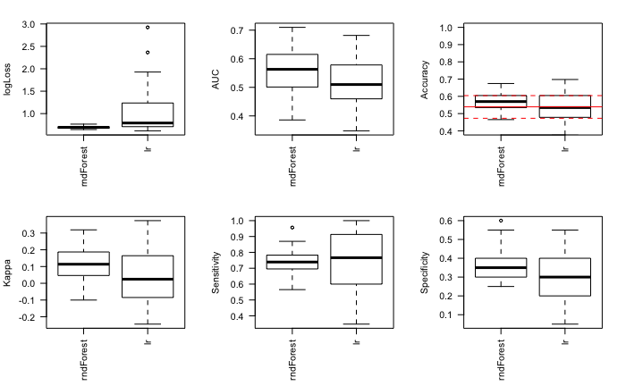

```r
phen_vars = which(grepl("_thickness$", colnames(X)))
ldata = X[, phen_vars]
groups = y
root_fname = '~/data/baseline_prediction/results/stripped_structThickness_NVvsADHD_big'
save(ldata, groups, file=sprintf('%s.RData', root_fname), compress=T)
#runInCluster(root_fname, train_test_ratio=.8, cpuDiff=2, nsplits=30, nrepeatcv=5, run_models=c('rndForest', 'lr'))
res = collect_results(root_fname)
mylist = res[[1]]
run_models = res[[2]]
source('~/ncr_notebooks/baseline_prediction/src/do_metrics_plots.R')
```

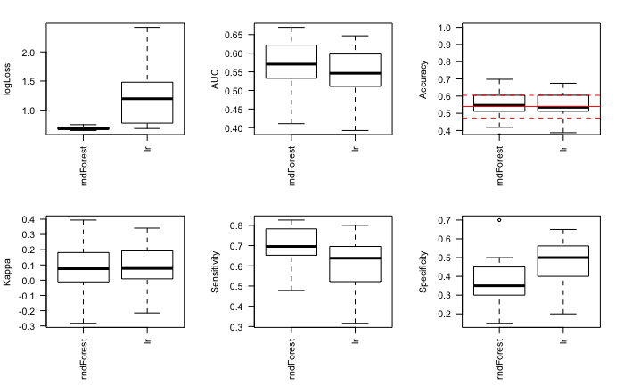

```r
phen_vars = which(grepl("_area$", colnames(X)))
ldata = X[, phen_vars]
groups = y
root_fname = '~/data/baseline_prediction/results/stripped_structArea_NVvsADHD_big'
save(ldata, groups, file=sprintf('%s.RData', root_fname), compress=T)
#runInCluster(root_fname, train_test_ratio=.8, cpuDiff=2, nsplits=30, nrepeatcv=5, run_models=c('rndForest', 'lr'))
res = collect_results(root_fname)
mylist = res[[1]]
run_models = res[[2]]
source('~/ncr_notebooks/baseline_prediction/src/do_metrics_plots.R')
```

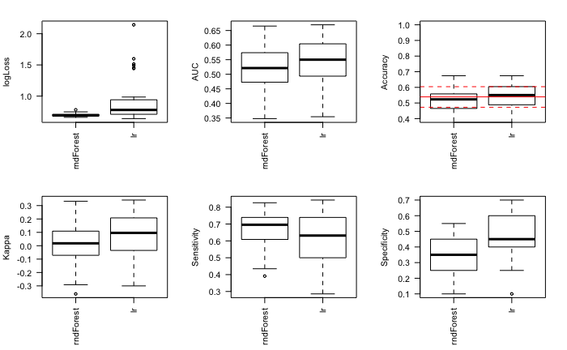

```r
phen_vars = which(grepl("_volume$", colnames(X)))
ldata = X[, phen_vars]
groups = y
root_fname = '~/data/baseline_prediction/results/stripped_structThickness_NVvsADHD_big'
save(ldata, groups, file=sprintf('%s.RData', root_fname), compress=T)
#runInCluster(root_fname, train_test_ratio=.8, cpuDiff=2, nsplits=30, nrepeatcv=5, run_models=c('rndForest', 'lr'))
res = collect_results(root_fname)
mylist = res[[1]]
run_models = res[[2]]
source('~/ncr_notebooks/baseline_prediction/src/do_metrics_plots.R')
```

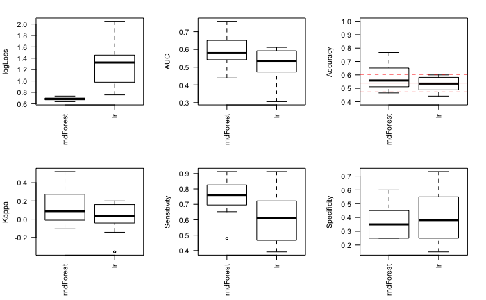

```r
phen_vars = c(which(grepl("_volume$", colnames(X))),
              which(grepl("_thickness$", colnames(X))),
              which(grepl("_area$", colnames(X))))
ldata = X[, phen_vars]
groups = y
root_fname = '~/data/baseline_prediction/results/stripped_structAllCortical_NVvsADHD_big'
save(ldata, groups, file=sprintf('%s.RData', root_fname), compress=T)
#runInCluster(root_fname, train_test_ratio=.8, cpuDiff=2, nsplits=30, nrepeatcv=5, run_models=c('rndForest', 'lr'))
res = collect_results(root_fname)
mylist = res[[1]]
run_models = res[[2]]
source('~/ncr_notebooks/baseline_prediction/src/do_metrics_plots.R')
```

# Let’s look into the subdivision Philip made:

```r
regional = read.csv('~/data/baseline_prediction/REGIONAL_ANALYSES_FREESURFER.csv')
sublobar_regions = unique(regional$subloar)
# for each region, add or average the columns corresponding to the ROIs
area_data = c()
hdr = c()
volume_data = c()
thickness_data = c()
aparc_data = c()
aparc_hdr = c()
for (s in sublobar_regions) {
  if (s != "") {
    idx = which(regional$subloar == s)
    area = 0
    volume = 0
    thickness = 0
    aparc = 0
    for (i in idx) {
      cnt = 0
      roi_name = sub('_thickness', '', regional[i, 1])
      if (length(grep('rh_|lh_', roi_name)) > 0) {
        var_name = quote(sprintf('%s_area', roi_name))
        area = area + X[, eval(var_name)]
        var_name = quote(sprintf('%s_volume', roi_name))
        volume = volume + X[, eval(var_name)]
        var_name = quote(sprintf('%s_thickness', roi_name))
        thickness = thickness + X[, eval(var_name)]
        cnt = cnt + 1
      }
      else {
        var_name = quote(roi_name)
        aparc = aparc + X[, eval(var_name)]
      }
    }
    if (sum(area) > 0) {
      hdr = c(hdr, s)
      area_data = cbind(area_data, area)
      volume_data = cbind(volume_data, volume)
      thickness_data = cbind(thickness_data, thickness / cnt)
    }
    else {
      aparc_hdr = c(aparc_hdr, s)
      aparc_data = cbind(aparc_data, aparc)
    }
  }
}
colnames(area_data) = hdr
colnames(volume_data) = hdr
colnames(thickness_data) = hdr
colnames(aparc_data) = aparc_hdr
```

And we do the same thing for lobar:

```r
regional = read.csv('~/data/baseline_prediction/REGIONAL_ANALYSES_FREESURFER.csv')
lobar_regions = unique(regional$lobar)
# for each region, add or average the columns corresponding to the ROIs
areaLobar_data = c()
hdr = c()
volumeLobar_data = c()
thicknessLobar_data = c()
aparcLobar_data = c()
aparc_hdr = c()
for (s in lobar_regions) {
  if (s != "") {
    idx = which(regional$lobar == s)
    area = 0
    volume = 0
    thickness = 0
    aparc = 0
    for (i in idx) {
      cnt = 0
      roi_name = sub('_thickness', '', regional[i, 1])
      if (length(grep('rh_|lh_', roi_name)) > 0) {
        var_name = quote(sprintf('%s_area', roi_name))
        area = area + X[, eval(var_name)]
        var_name = quote(sprintf('%s_volume', roi_name))
        volume = volume + X[, eval(var_name)]
        var_name = quote(sprintf('%s_thickness', roi_name))
        thickness = thickness + X[, eval(var_name)]
        cnt = cnt + 1
      }
      else {
        var_name = quote(roi_name)
        aparc = aparc + X[, eval(var_name)]
      }
    }
    if (sum(area) > 0) {
      hdr = c(hdr, s)
      areaLobar_data = cbind(areaLobar_data, area)
      volumeLobar_data = cbind(volumeLobar_data, volume)
      thicknessLobar_data = cbind(thicknessLobar_data, thickness / cnt)
    }
    else {
      aparc_hdr = c(aparc_hdr, s)
      aparcLobar_data = cbind(aparcLobar_data, aparc)
    }
  }
}
colnames(areaLobar_data) = hdr
colnames(volumeLobar_data) = hdr
colnames(thicknessLobar_data) = hdr
colnames(aparcLobar_data) = aparc_hdr
```

And finally, we do it for the theory driven cases:

```r
regional = read.csv('~/data/baseline_prediction/REGIONAL_ANALYSES_FREESURFER.csv')
theory_regions = unique(regional$ROI_theory_driven)
# for each region, add or average the columns corresponding to the ROIs
areaTheory_data = c()
hdr = c()
volumeTheory_data = c()
thicknessTheory_data = c()
aparcTheory_data = c()
aparc_hdr = c()
for (s in theory_regions) {
  if (s != "") {
    idx = which(regional$ROI_theory_driven == s)
    area = 0
    volume = 0
    thickness = 0
    aparc = 0
    for (i in idx) {
      cnt = 0
      roi_name = sub('_thickness', '', regional[i, 1])
      if (length(grep('rh_|lh_', roi_name)) > 0) {
        var_name = quote(sprintf('%s_area', roi_name))
        area = area + X[, eval(var_name)]
        var_name = quote(sprintf('%s_volume', roi_name))
        volume = volume + X[, eval(var_name)]
        var_name = quote(sprintf('%s_thickness', roi_name))
        thickness = thickness + X[, eval(var_name)]
        cnt = cnt + 1
      }
      else {
        var_name = quote(roi_name)
        aparc = aparc + X[, eval(var_name)]
      }
    }
    if (sum(area) > 0) {
      hdr = c(hdr, s)
      areaTheory_data = cbind(areaTheory_data, area)
      volumeTheory_data = cbind(volumeTheory_data, volume)
      thicknessTheory_data = cbind(thicknessTheory_data, thickness / cnt)
    }
    else {
      aparc_hdr = c(aparc_hdr, s)
      aparcTheory_data = cbind(aparcTheory_data, aparc)
    }
  }
}
colnames(areaTheory_data) = hdr
colnames(volumeTheory_data) = hdr
colnames(thicknessTheory_data) = hdr
colnames(aparcTheory_data) = aparc_hdr
```

## Lobar

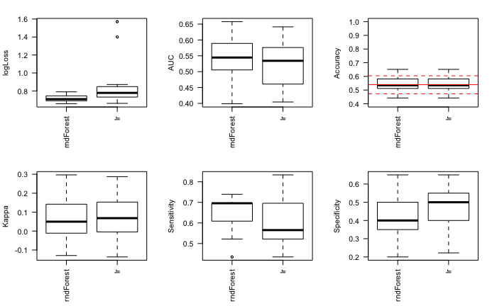

```r
ldata = areaLobar_data
groups = y
root_fname = '~/data/baseline_prediction/results/stripped_structAreaLobar_NVvsADHD_big'
save(ldata, groups, file=sprintf('%s.RData', root_fname), compress=T)
#runInCluster(root_fname, train_test_ratio=.8, cpuDiff=2, nsplits=30, nrepeatcv=5, run_models=c('rndForest', 'lr'))
res = collect_results(root_fname)
mylist = res[[1]]
run_models = res[[2]]
source('~/ncr_notebooks/baseline_prediction/src/do_metrics_plots.R')
```

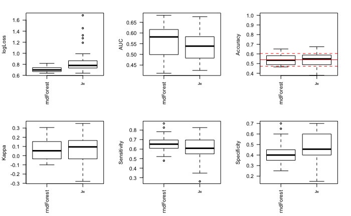

```r
ldata = thicknessLobar_data
groups = y
root_fname = '~/data/baseline_prediction/results/stripped_structThicknessLobar_NVvsADHD_big'
save(ldata, groups, file=sprintf('%s.RData', root_fname), compress=T)
#runInCluster(root_fname, train_test_ratio=.8, cpuDiff=2, nsplits=30, nrepeatcv=5, run_models=c('rndForest', 'lr'))
res = collect_results(root_fname)
mylist = res[[1]]
run_models = res[[2]]
source('~/ncr_notebooks/baseline_prediction/src/do_metrics_plots.R')
```

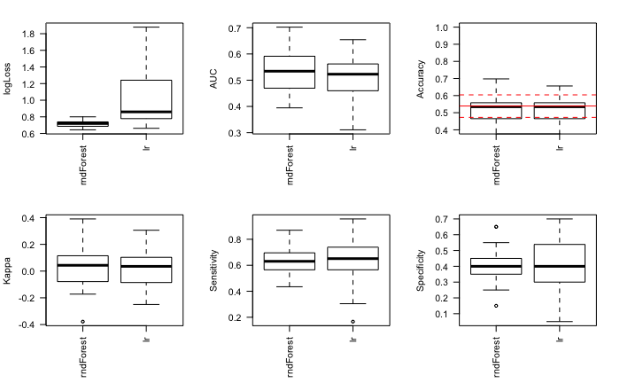

```r
ldata = volumeLobar_data
groups = y
root_fname = '~/data/baseline_prediction/results/stripped_structVolumeLobar_NVvsADHD_big'
save(ldata, groups, file=sprintf('%s.RData', root_fname), compress=T)
#runInCluster(root_fname, train_test_ratio=.8, cpuDiff=2, nsplits=30, nrepeatcv=5, run_models=c('rndForest', 'lr'))
res = collect_results(root_fname)
mylist = res[[1]]
run_models = res[[2]]
source('~/ncr_notebooks/baseline_prediction/src/do_metrics_plots.R')
```

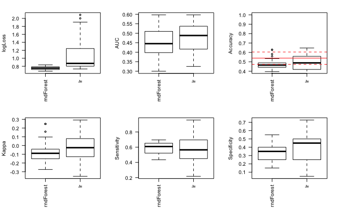

```r
ldata = aparcLobar_data
groups = y
root_fname = '~/data/baseline_prediction/results/stripped_structAparcLobar_NVvsADHD_big'
save(ldata, groups, file=sprintf('%s.RData', root_fname), compress=T)
#runInCluster(root_fname, train_test_ratio=.8, cpuDiff=2, nsplits=30, nrepeatcv=5, run_models=c('rndForest', 'lr'))
res = collect_results(root_fname)
mylist = res[[1]]
run_models = res[[2]]
source('~/ncr_notebooks/baseline_prediction/src/do_metrics_plots.R')
```

## Sublobar

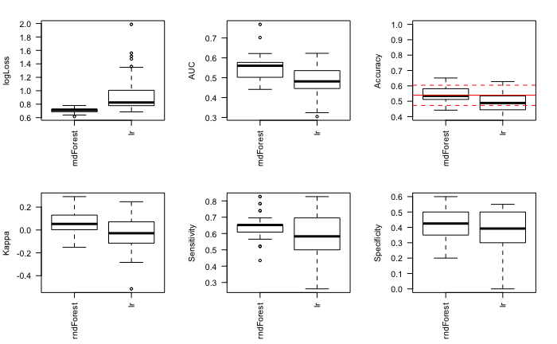

```r
ldata = area_data
groups = y
root_fname = '~/data/baseline_prediction/results/stripped_structAreaSublobar_NVvsADHD_big'
save(ldata, groups, file=sprintf('%s.RData', root_fname), compress=T)
#runInCluster(root_fname, train_test_ratio=.8, cpuDiff=2, nsplits=30, nrepeatcv=5, run_models=c('rndForest', 'lr'))
res = collect_results(root_fname)
mylist = res[[1]]
run_models = res[[2]]
source('~/ncr_notebooks/baseline_prediction/src/do_metrics_plots.R')
```

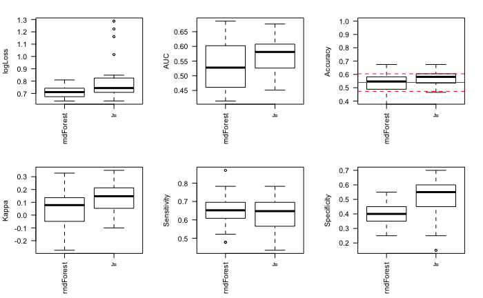

```r
ldata = thickness_data
groups = y
root_fname = '~/data/baseline_prediction/results/stripped_structThicknessSublobar_NVvsADHD_big'
save(ldata, groups, file=sprintf('%s.RData', root_fname), compress=T)
#runInCluster(root_fname, train_test_ratio=.8, cpuDiff=2, nsplits=30, nrepeatcv=5, run_models=c('rndForest', 'lr'))
res = collect_results(root_fname)
mylist = res[[1]]
run_models = res[[2]]
source('~/ncr_notebooks/baseline_prediction/src/do_metrics_plots.R')
```

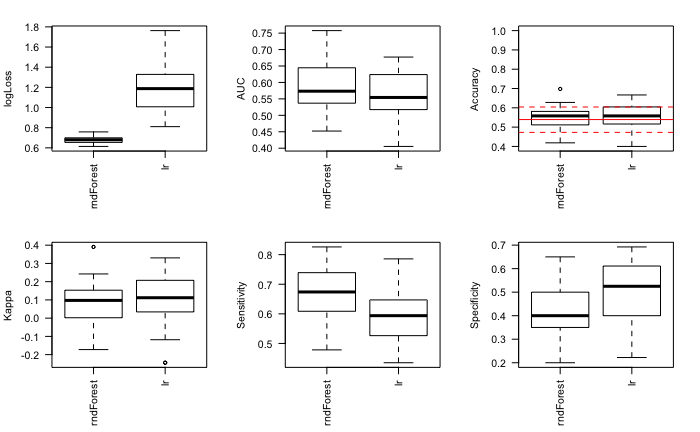

```r
ldata = volume_data
groups = y
root_fname = '~/data/baseline_prediction/results/stripped_structVolumeSublobar_NVvsADHD_big'
save(ldata, groups, file=sprintf('%s.RData', root_fname), compress=T)
#runInCluster(root_fname, train_test_ratio=.8, cpuDiff=2, nsplits=30, nrepeatcv=5, run_models=c('rndForest', 'lr'))
res = collect_results(root_fname)
mylist = res[[1]]
run_models = res[[2]]
source('~/ncr_notebooks/baseline_prediction/src/do_metrics_plots.R')
```

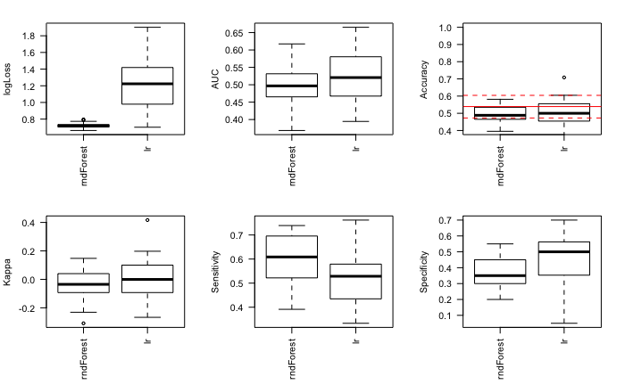

```r
ldata = aparc_data
groups = y
root_fname = '~/data/baseline_prediction/results/stripped_structAparcSublobar_NVvsADHD_big'
save(ldata, groups, file=sprintf('%s.RData', root_fname), compress=T)
#runInCluster(root_fname, train_test_ratio=.8, cpuDiff=2, nsplits=30, nrepeatcv=5, run_models=c('rndForest', 'lr'))
res = collect_results(root_fname)
mylist = res[[1]]
run_models = res[[2]]
source('~/ncr_notebooks/baseline_prediction/src/do_metrics_plots.R')
```

## Theory

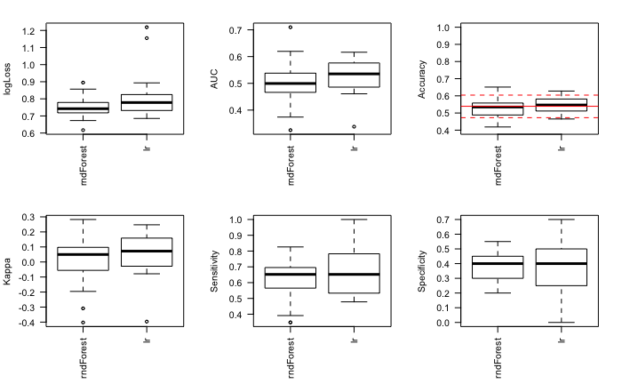

```r
ldata = areaTheory_data
groups = y
root_fname = '~/data/baseline_prediction/results/stripped_structAreaTheory_NVvsADHD_big'
save(ldata, groups, file=sprintf('%s.RData', root_fname), compress=T)
#runInCluster(root_fname, train_test_ratio=.8, cpuDiff=2, nsplits=30, nrepeatcv=5, run_models=c('rndForest', 'lr'))
res = collect_results(root_fname)
mylist = res[[1]]
run_models = res[[2]]
source('~/ncr_notebooks/baseline_prediction/src/do_metrics_plots.R')
```

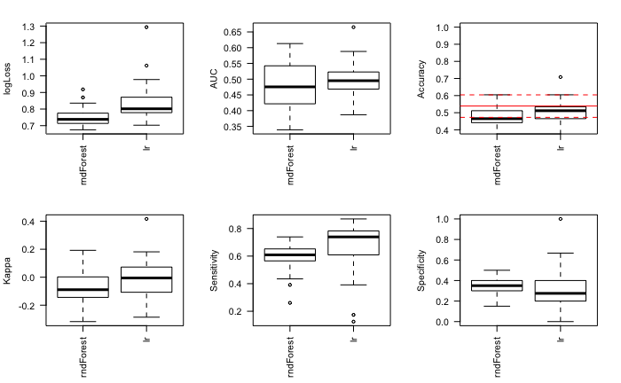

```r
ldata = thicknessTheory_data
groups = y
root_fname = '~/data/baseline_prediction/results/stripped_structThicknessTheory_NVvsADHD_big'
save(ldata, groups, file=sprintf('%s.RData', root_fname), compress=T)
#runInCluster(root_fname, train_test_ratio=.8, cpuDiff=2, nsplits=30, nrepeatcv=5, run_models=c('rndForest', 'lr'))
res = collect_results(root_fname)
mylist = res[[1]]
run_models = res[[2]]
source('~/ncr_notebooks/baseline_prediction/src/do_metrics_plots.R')
```

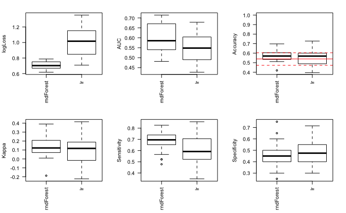

```r
ldata = volumeTheory_data
groups = y
root_fname = '~/data/baseline_prediction/results/stripped_structVolumeTheory_NVvsADHD_big'
save(ldata, groups, file=sprintf('%s.RData', root_fname), compress=T)
#runInCluster(root_fname, train_test_ratio=.8, cpuDiff=2, nsplits=30, nrepeatcv=5, run_models=c('rndForest', 'lr'))
res = collect_results(root_fname)
mylist = res[[1]]
run_models = res[[2]]
source('~/ncr_notebooks/baseline_prediction/src/do_metrics_plots.R')
```

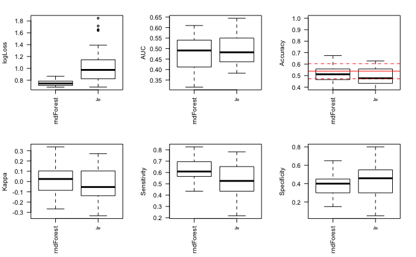

```r
ldata = aparcTheory_data
groups = y
root_fname = '~/data/baseline_prediction/results/stripped_structAparcTheory_NVvsADHD_big'
save(ldata, groups, file=sprintf('%s.RData', root_fname), compress=T)
#runInCluster(root_fname, train_test_ratio=.8, cpuDiff=2, nsplits=30, nrepeatcv=5, run_models=c('rndForest', 'lr'))
res = collect_results(root_fname)
mylist = res[[1]]
run_models = res[[2]]
source('~/ncr_notebooks/baseline_prediction/src/do_metrics_plots.R')
```

No matter how we slice it, the structural data doesn’t seem to do a good job in predicting ADHD vs NV. I could try replicating the exact same thing one of those papers did, with RFE, but I think I should focus on the other datasets and decision targets first.